# Take-home Exercise 4

In this take-home exercise 4, we will examine the daily routines of two selected participant of the city of Engagement, Ohio USA.

Hulwana Saifulzaman https://www.linkedin.com/in/hulwana-saifulzaman/ (SMU, Master of IT in Business)https://scis.smu.edu.sg/master-it-business  
2022-05-23

## 1. Overview

In this take-home exercise 4, we will examine the daily routines of two selected participant of the city of Engagement, Ohio USA.

## 2. Getting Started

Before we get started, it is important for us to ensure that the required R packages have been installed. If yes, we will load the R packages. If they have yet to be installed, we will install the R packages and load them onto R environment.

The chunk code below will do the trick.

```r
packages = c( 'lubridate', 'patchwork',
             'gridExtra', 'tidyverse','knitr',
             'data.table', 'clock')

for (p in packages){
  if(!require(p, character.only = T)){
    install.packages(p)
  }
  library(p,character.only = T)
}
```

## 3. Dataset

The *TravelJournal* and *CheckinJournal* dataset has been obtained from the *Journals* folder retrieved from [**Vast Challenge 2022**](https://vast-challenge.github.io/2022/) website.

### 3.1. Importing Data

The code chunk below import *TravelJournal.csv* and *CheckinJournal.csv* from the data folder by using [`read_csv()`](https://readr.tidyverse.org/reference/read_delim.html) of [**readr**](https://readr.tidyverse.org/) into R and save it as an tibble data frame called *travel* and *venue*.

```r
travel <- read_csv("data/TravelJournal.csv")

venue <- read_csv("data/CheckinJournal.csv")
```

### 3.2. Data Preparation

#### 3.2.1. Extract the venue type from *venue* dataset

As the end location of the participants are not readily identifiable in the *travel* dataset, we will mapped the *travelEndLocationId* to the venue type obtained from the *venue* dataset.

Below is the code to get the distinct *venueId* and its corresonpding *venueType*.

```r
venue_map <- venue %>% select(venueId, venueType) %>% distinct()
```

#### 3.2.2. Join the 2 datasets

Left join the *travel* dataset with *venue_map* to identify the end location.

```r
location <- merge(travel, venue_map, by.x = 'travelEndLocationId', by.y = 'venueId', all.x = TRUE)
```

#### 3.2.3. Identify the times where participants are travelling

As there are 2 sets of start and end time for each observation, we will first need to get the interval where participants are travelling.

```r
transport <- location %>%
  select(participantId, travelStartTime, travelEndTime) %>%
  mutate(activity = "Transport")

names(transport)[2] <- "startTime"
names(transport)[3] <- "endTime"
```

#### 3.2.4. Identify the times where participants are at a certain loacation

```r
place <- location %>%
  select(participantId, checkInTime, checkOutTime, venueType)

names(place)[2] <- "startTime"
names(place)[3] <- "endTime"
names(place)[4] <- "activity"
```

#### 3.2.5. Merge both *transport* and *place*

```r
activity <- rbind(place, transport)
```

## 4. Comparing the daily pattern of 2 participants

### 4.1 Weekly pattern for *participantId* 100 and 200

Participant with ID 100 and 200 are selected for comparison. We will compare their weekly pattern between 7 March 2022 - 13 March 2022.

To examine the pattern and duration spent by each participant at the respective location, we will use [`geom_segment()`](https://ggplot2.tidyverse.org/reference/geom_segment.html) from the [`ggplot2`](https://ggplot2.tidyverse.org/index.html) package.

### 4.1.1. Extract weekly data for participant 100 and 200

```r
pattern <- activity %>% filter(participantId == 100 | participantId == 200) %>%
  filter(as.character(endTime) > "2022-03-07 00:00:00") %>%
  filter(as.character(startTime) < "2022-03-14 00:00:00")
```

### 4.1.2. Plot the weekly routine for participant 100 and 200

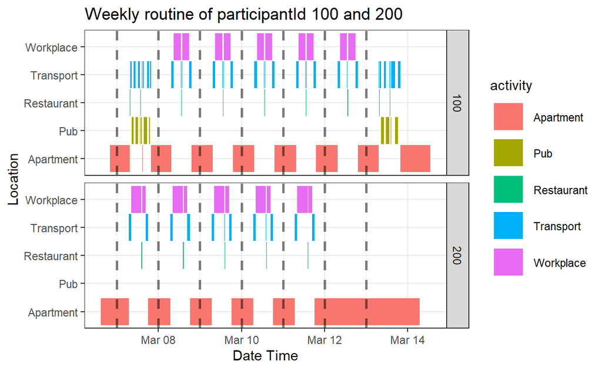

```r
pl <- ggplot(pattern) +
geom_segment(aes(x=activity, xend=activity, y=startTime, yend=endTime, color = activity), size = 10) +
geom_hline(yintercept = as_datetime("2022-03-07 00:00:00"), color = "black",
           linetype = 'dashed', size = 1, alpha = 0.5) +
geom_hline(yintercept = as_datetime("2022-03-08 00:00:00"), color = "black",
           linetype = 'dashed', size = 1, alpha = 0.5) +
geom_hline(yintercept = as_datetime("2022-03-09 00:00:00"), color = "black",
           linetype = 'dashed', size = 1, alpha = 0.5) +
geom_hline(yintercept = as_datetime("2022-03-10 00:00:00"), color = "black",
           linetype = 'dashed', size = 1, alpha = 0.5) +
geom_hline(yintercept = as_datetime("2022-03-11 00:00:00"), color = "black",
           linetype = 'dashed', size = 1, alpha = 0.5) +
geom_hline(yintercept = as_datetime("2022-03-12 00:00:00"), color = "black",
           linetype = 'dashed', size = 1, alpha = 0.5) +
geom_hline(yintercept = as_datetime("2022-03-13 00:00:00"), color = "black",
           linetype = 'dashed', size = 1, alpha = 0.5) +
theme_bw() +
facet_grid(participantId ~ .)+
labs(x = 'Location', y = "Date Time", title = "Weekly routine of participantId 100 and 200" ) +
coord_flip()

pl
```

### 4.2.1. Extract 8 March 2022 data for participant 100 and 200

```r
pattern2 <- activity %>% filter(participantId == 100 | participantId == 200) %>%
  filter(as.character(endTime) > "2022-03-08 00:00:00") %>%
  filter(as.character(endTime) < "2022-03-09 08:00:00")
```

### 4.2.2. Plot Tuesday, 8 March 2022 routine for both participants

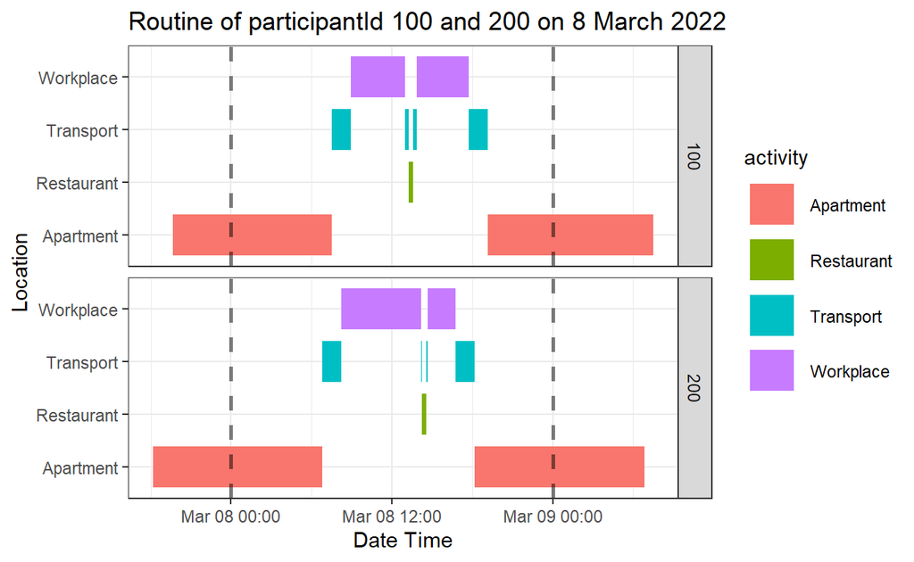

```r
pl2 <- ggplot(pattern2) +
geom_segment(aes(x=activity, xend=activity, y=startTime, yend=endTime,
                             color = activity), size = 10) +
geom_hline(yintercept = as_datetime("2022-03-07 00:00:00"), color = "black",
           linetype = 'dashed', size = 1, alpha = 0.5) +
geom_hline(yintercept = as_datetime("2022-03-08 00:00:00"), color = "black",
           linetype = 'dashed', size = 1, alpha = 0.5) +
geom_hline(yintercept = as_datetime("2022-03-09 00:00:00"), color = "black",
           linetype = 'dashed', size = 1, alpha = 0.5) +
geom_hline(yintercept = as_datetime("2022-03-10 00:00:00"), color = "black",
           linetype = 'dashed', size = 1, alpha = 0.5) +
theme_bw() +
facet_grid(participantId ~ .)+
labs(x = 'Location', y = "Date Time", title = "Routine of participantId 100 and 200 on 8 March 2022" ) +
coord_flip()

pl2
```

Based on the chart plotted above, we notice the following similarities and differences between *participantId* 100 and 200:

#### Work

● Similarities : Both participant 100 and 200 work 5 days a week. ● Differences : Participant 100 works from Tuesday - Saturday whereas participant 200 works from Monday - Friday. Participant 100 starts and end work slightly later as compared to participant 200.

#### Lunch

● Differences : Participant 200 goes for lunch at a much later timing as compared to participant 100. Participant 200 takes lesser time to travel from work to the eating place as compares to participant 100.

#### Commute home from work

● Similarities : The commute home from work is roughly the same for both participants.

#### Going Home

● Differences : As participant 200 ends work slightly earlier, participant 200 also reaches home slighlty earlier than participant 100.

#### Recreation

● Similarities : Both participants do not go to pubs on working days. ● Differences : For this particular week, participant 200 does not go to the pub whereas particpant 100 goes on non-working days.

#### Weekends

● Differences : Participant 200 spent the weekend at home whereas participant 100 went out to the restaurant and pubs.